# Adding Level Progression

It’s time to make sure these events work in the game.

Open the `res://Game.tscn` and delete the current *Level* node. Then instance the `res://Levels/Level1.tscn` as child of the *Game*.

Before we test our brand new level, note that we made some connections from the *Level* to the *Game* by hand in the *Main Game Loop* lesson. It’s time to automate the setting up of the *Level* now that we might have multiple levels. This will allow us to load new levels and prevent us from handling signal connections through the editor itself.

## Setting up the Level

Open the `res://Game.gd` script and we move some lines from the `_ready()` callback to a dedicated method. We create a method to setup levels which takes the current `_level` and makes the signal connections we made by hand. It also links the `_level.tower_placer` with the `_tower_shop`.

`Game.gd`

```
func _setup_level() -> void:
  # Connects the Level signals to Game's callbacks
    _level.connect("base_destroyed", self, "_on_Level_base_destroyed")
    _level.connect("finished", self, "_on_Level_finished")
    _level.connect("gold_earned", self, "_on_Level_gold_earned")
    _level.connect("round_finished", self, "_on_Level_round_finished")

  # Link the TowerShop with the Level's TowerPlacer
    _level.tower_placer.connect("tower_placed", _tower_shop, "_on_TowerPlacer_tower_placed")
    _tower_shop.connect("tower_purchased", _level.tower_placer, "add_new_tower")
```

With that we can call this method in the `_ready()` callback and start the level knowing it has been setup correctly.

`Game.gd`

```
func _ready() -> void:
    _tower_shop.player = _player
    _gold_panel.player = _player
    _setup_level()
    _level.start()
```

Now we can play the game and test if players can make it to the end of the level.

Before playing the game, make sure the visibility of nodes is correct.

[figure not shown]

Our game shouldn’t have a single level, right? And even if it does, we should at least display an end screen telling that the player finished the game.

## Progressing through levels

To progress through levels, we should have at least one more level. Let’s create another inherited scene using the `res://Levels/Level.tscn` as base. Remember, this is our template scene, our blueprint. Save the new inherited scene as `res://Levels/Level2.tscn`.

Here we can make different scenarios, add new events, harder enemies…be creative!

In our version of the game, the exploration team found some gold mines and they moved their buildings next to it. The team also finds some gold ore and the player gains `500` gold! We added a *Call Method Track* at the beginning of a dialogue which calls the `emit_signal()` method with two arguments. The first one is a

[figure not shown]

`String` with the signal name, the second one is the amount of gold earned.

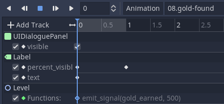

Here’s a closer look to the *Call Method Track*’s key in the *Inspector*.

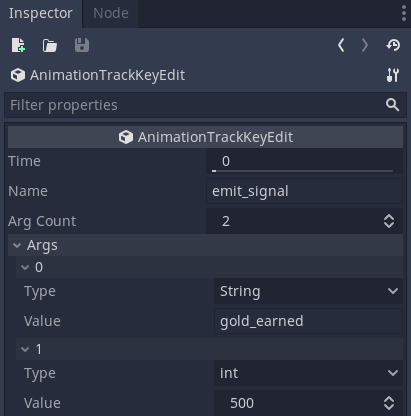

We also changed the map to reflect the new scenario and themed it according to the story we’re telling. You could even move the *StartPoint* to a mine to give the idea that enemies are coming out of it!

With our second level in place, let’s open the `Level.gd` script. In our level transition system, each level will carry a reference to the next level’s path. Export a `next_level_path` variable. As this should always be a path to a

[figure not shown]

`PackedScene` resource, we can use export hints to allow us to filter files when we search for the scene we’ll use.

`Level.gd`

```
# Exports a string variable with the FILE context, allowing us to select a file
# from the file browser popup menu. It should only files that ends with
# "*.tscn".
export(String, FILE, "*.tscn") var next_level_path
```

Open `res://Levels/Level1.tscn` and set the `next_level_path` to point to the `res://Levels/Level2.tscn` file.

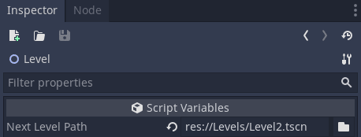

## Loading new levels

Now that each level can point to next one, we can use this data to load and setup new levels. Back to the `Game.gd` script, we create a method that loads the next level, sets it up, and starts it.

`Game.gd`

```
func _load_next_level() -> void:
  # Load and instance the next level's PackedScene
    var next_level: Node = load(_level.next_level_path).instance()

  # Take rid of the current level and sets the new level as the current `_level`
    _level.queue_free()
    _level = next_level

  # Add the new _level as a Game's child, set it up, and start it
    add_child(_level)
    _setup_level()
    _level.start()
```

When the player finishes the current level, we should load the next one. We yield for the completion of the `_screen_overlay.play_win()` method in the `_on_Level_finished()` signal callback. Remember, this is an asynchronous method; it only completes when the animation finishes. After that, we check if the current level has a `next_level_path` to load. If it has, we load the next level.

`Game.gd`

```
func _on_Level_finished() -> void:
    yield(_screen_overlay.play_win(), "completed")
    if _level.next_level_path:
        _load_next_level()
```

Now let’s check if our system is working. As the *EventsPlayer* has its current event as an exported variable, we can start the level from any event. Including the last one, which will make our test easier. Open the `Level1.tscn` scene and set the *EventsPlayer > Current Event* to match the index of the last event. Do the same for the `Level2.tscn` scene and play the game!

Remember to set *EventPlayer > Current Event* back to `0` for each level.

## Finishing the game

It’s time to tell players their journey has come to an end, congratulate them and show how they did. In the starting project, you can find the `res://Screens/EndScreen.tscn`. It’s a scene that plays an animation popping a panel with a message and the player’s score.

Note that in the *EndScreen > Panel > Label > Text* we have a placeholder string at the end of the text: `%s`. In the script, we use the `player_score` variable to replace this placeholder in the `_ready()` callback. How will we get this value in run time? And why is this variable exported?

Well, open the `res://Game.gd` script. Let’s code what happens when the level finishes and there’s no `next_level_path` to load.

`Game.gd`

```
# Initializes the user interface, forwarding it the data it needs from the game
# world.
extends Node

export(String, FILE, "*tscn") var end_screen_path = "res://Screens/EndScreen.tscn"
```

In the `_on_Level_finished()` callback, we dynamically modify the end screen

[figure not shown]

`PackedScene` and tell the `SceneTree` to change to it. Remember scenes are serialized nodes, so we can change a node property in run time and repack it. That’s why it’s important to have the `player_score` serialized.

If we had more complex data to load and store, it would be a good idea to dump it into a save file and load it between scenes. But with the quick game we’ve designed, it’s easier to pass the data to the only class that will use it.

In our script, we instance the end screen and set its `player_score` to be the current `_player.gold`. The resulting gold means how well players spent their resources, so it’s a good metric for performance. The greater the gold amount, the better the strategy the player used.

We create a new

[figure not shown]

`PackedScene` and use its `pack()` method to repack the end screen with the updated score.

Finally, we use the `SceneTree` to change the current scene to the scene we packed. This is how the `_on_Level_finished()` callback will look like at the end.

`Game.gd`

```
func _on_Level_finished() -> void:
  # Wait for the win animation completion
    yield(_screen_overlay.play_win(), "completed")

  # Load the next level if any
    if _level.next_level_path:
        _load_next_level()
  # In case there's no level to load anymore, load the end screen
    else:
    # Instance the EndScreen packed scene and update its `player_score`
        var end_screen: Node = load(end_screen_path).instance()
        end_screen.player_score = _player.gold

    # Create a new PackedScene that packs the EndScreen instance, keeping its
    # data
        var packed_scene := PackedScene.new()
        packed_scene.pack(end_screen)

    # Change the scene to the updated EndScreen
        get_tree().change_scene_to(packed_scene)
```

With that, whenever we want a level to be the last level, we can keep its `next_level_path` empty and the game will understand that the player completed all the levels.

If we test the game now, we should see something like this after playing the last level.

[figure not shown]

We have our first screen loop! Being able to loop between different screens really makes the difference for players. As a tip, you can use the `change_scene()` method when you don’t want to pass a

[figure not shown]

`PackedScene` like we just did.

And there we have it, from here you’re able to re-skin the project and make lots of content for your own tower defense game! Tell a nice story, make themed levels, present new enemies, maybe even bosses!